# Loan Data from Prosper: Communicate Data Findings

## by Nkemakolam Onyemachi

## Investigation Preview

> In this analysis, I wanted to investigate the relationships with the loan applications and the Borrowers' APR. Also with the investors. The main focus was on the original loan amount, borrower's Prosper rating, loan term, borrower's stated monthly income, Employment Status , Term and Occupation.

## Dataset Overview

> The dataset contains 83982 loans with 21 features (including LoanOriginalAmount, BorrowerAPR, StatedMonthlyIncome, ProsperRating (Alpha), EmploymentStatus and many others)

# Distribution of loans annually

- 2013 had the highest loan application

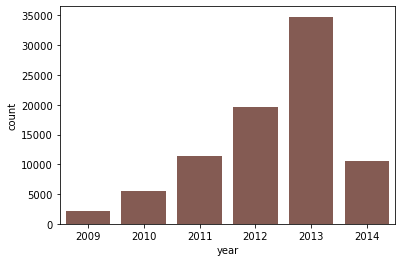

# Distribution of Borrower APR

- The borrower APR's peak is multimodal with largest peak from 0.30-0.37 while the smallest peak is from 0.0-0.1 and 0.4

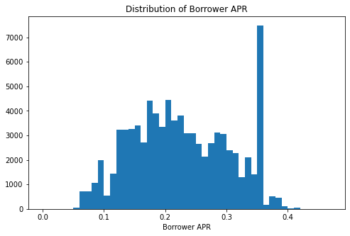

# Distribution of loan original amount

- Highest loan amount is between 1k to 5k while the lowest loan amount is 30k

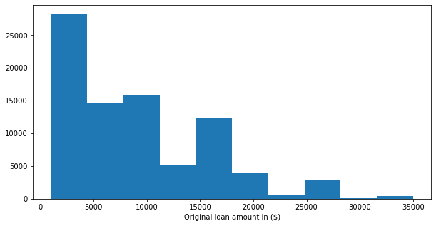

# Borrower APR vs. Loan Amount

The APR has a large range, but the range of APR decrease with the increase of loan amount. Overall, the borrower APR decrease with increase of loan amount

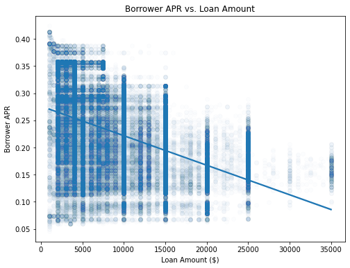

# Borrower's APR vs Prosper rating

- HR had the highest APR while AA had the lowest APR

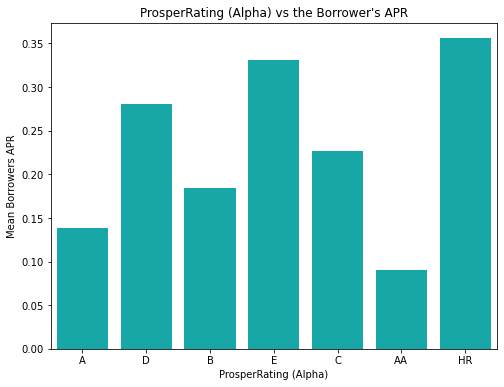

## Prosper ratings of Applicants

- The highetst number of loan applicant had C ratings while the least number had AA rating.

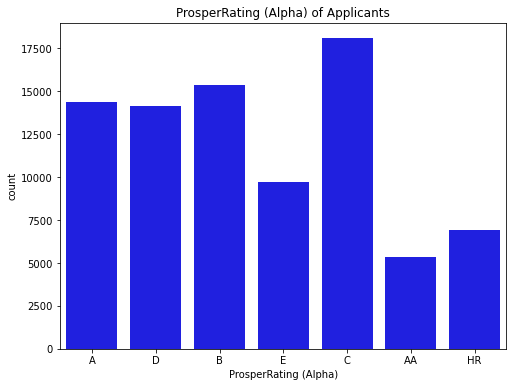

# Borrower APR vs Occupation

- The borrower APR changes with the occupation,Interestingly with student in technical schools having least and college sophomores having highest average rating.

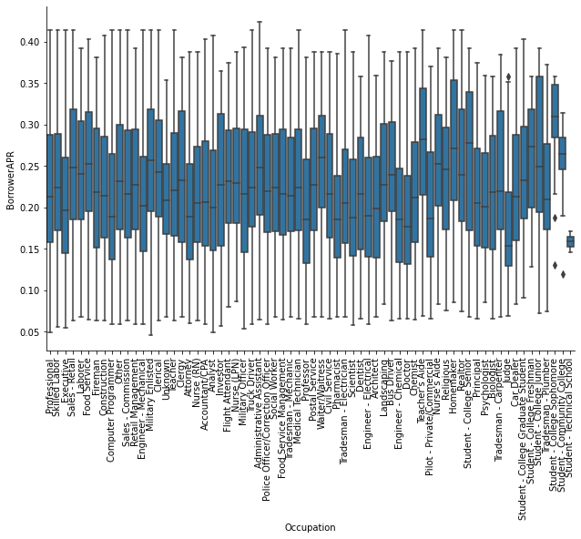

# Prosper Rating Effect on Relationship between APR and Loan Amount

- The graph is negative correlated in the 'HR' category to the loan amount and tends to positve when it reaches the 'A' category and the 'AA' category. The 'A' and 'AA' category has the lowest risk. It will be profitable to encourage them in this category to borrow more to get more profit.

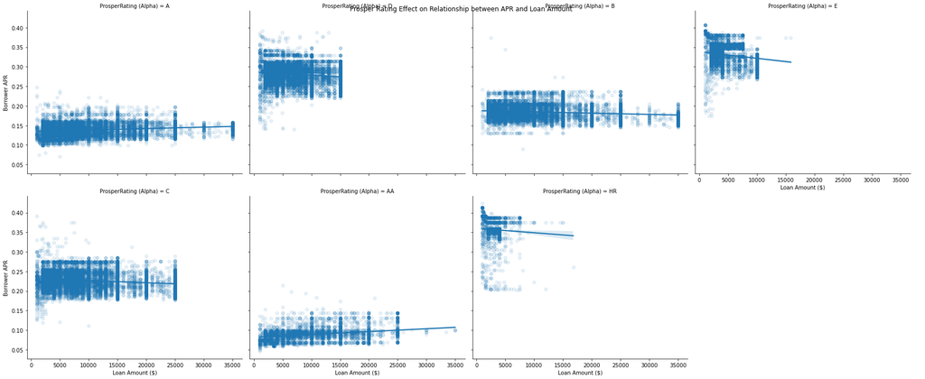

# StatedMonthlyIncome and LoanOriginalAmount by Rating and Term

- StatedMonthlyIncome and LoanOriginalAmount change with the increase in the borrow term and ratings on an average

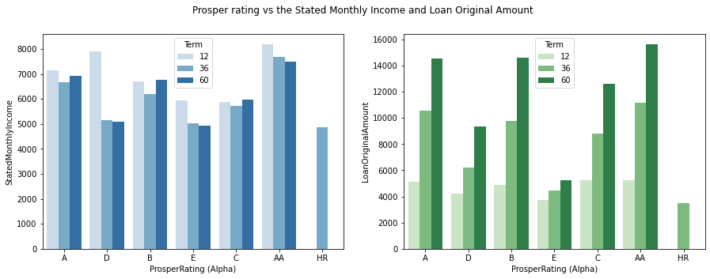

# Investors and the type of loans

- Investors like to invest in loan applicants who want to borrow money for business purposes. The highest number of applicants borrow for Debt consolidation

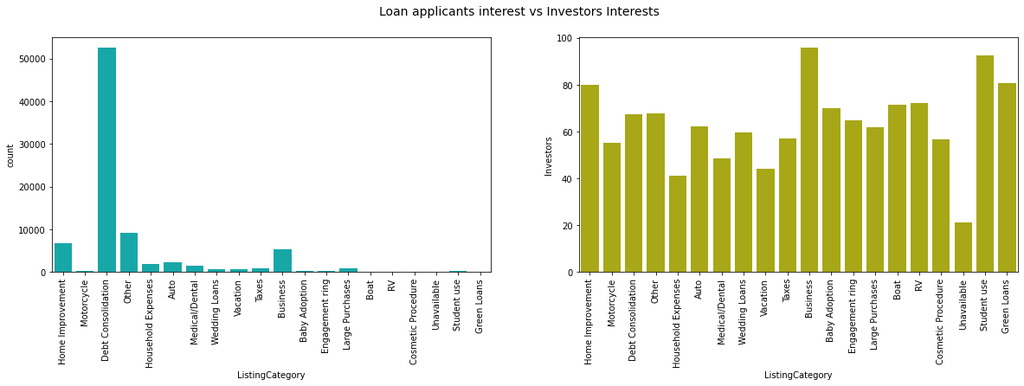

# Investor and Prosper rating

- The number of investors increases as the prosper rating gets better. The highest mean of investors in the Loan term was in 60months and in the "AA" category.

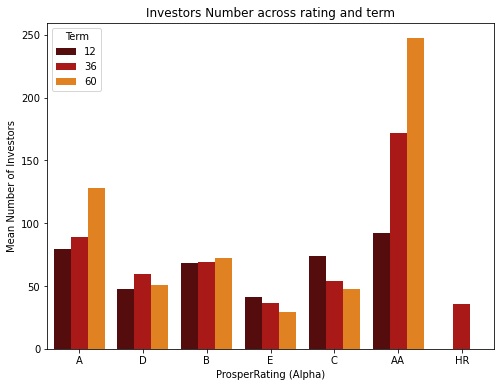